# Q & K Box 13.4

Fill et al (2021) studied the effect of duff (leaf litter) on the post-fire ecology of wiregrass (*Aristida beyrichiana*) in a section of pine savanna. They sampled 99 plants in an area of 0.1 km<sup>2</sup>, recorded plant basal area and allocated each plant to one of three treatments: high duff, low duff, low duff with added pine cones. They then burnt the area and five months later, counted the number of culms on each plant. We will model numbers of culms per plant against basal area and duff treatment using each plant as the unit of analysis.

This box explores several different ways in which count data can be treated, from the “classical” OLS models where the counts are square-root transformed, to GLMs based on the poisson distribution, to several options for data that are overdispersed.

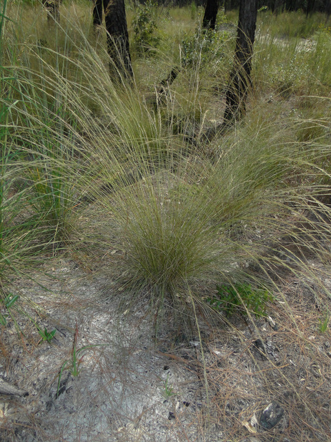

*Aristida beyrichiana*. [© Copyright Bobby Hattaway 2011/Discover Life](https://www.discoverlife.org/ap/copyright.html)

The paper is [here](https://doi.org/10.1371/journal.pone.0247159) and Figure 1 has relevant photos.

Fill, J. M., Zamora, C., Baruzzi, C., Salazar-Castro, J. & Crandall, R. M. (2021). Wiregrass (*Aristida beyrichiana*) survival and reproduction after fire in a long-unburned pine savanna. *PLoS One*, 16, e0247159.

### Preliminaries

First, load the required packages (car, performance, MuMIn, statmod, lmtest, vcd, Rmisc, MASS, pscl)

Import fill data file (fill.csv)

```r
fill <- read.csv("../data/fill.csv")
fill
```

| culm | reprod | basalarea | treatment |
| --- | --- | --- | --- |
| 8 | 1 | 11.83780 | High Duff |
| 19 | 1 | 160.92500 | High Duff |
| 3 | 1 | 15.93550 | High Duff |
| 9 | 1 | 84.78000 | High Duff |
| 44 | 1 | 346.97000 | High Duff |
| 15 | 1 | 82.15025 | High Duff |
| 4 | 1 | 43.52040 | High Duff |
| 0 | 0 | 8.24250 | High Duff |
| 1 | 1 | 41.01625 | High Duff |
| 1 | 1 | 229.69100 | High Duff |

[output cut: 89 more lines]

Check culm distribution with histogram

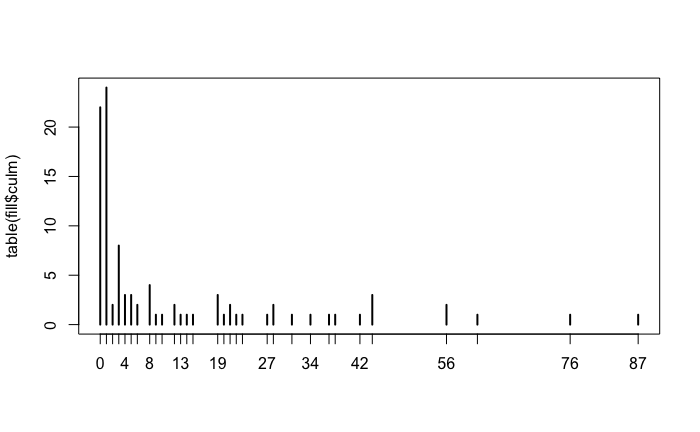

```r
plot(table(fill$culm))
```

Boxplot against treatment

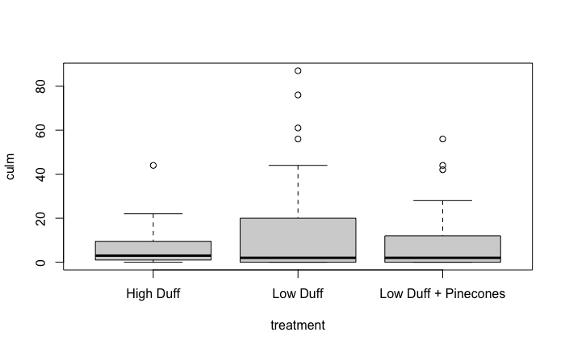

```r
boxplot(culm~treatment, data=fill)
```

Data possibly over-dispersed for poisson

```r
summarySE(data=fill, measurevar="culm", groupvars=c("treatment"))
```

| treatment | N | culm | sd | se | ci |
| --- | --- | --- | --- | --- | --- |
| High Duff | 28 | 7.464286 | 9.931179 | 1.876816 | 3.850909 |
| Low Duff | 46 | 13.739130 | 21.714752 | 3.201665 | 6.448485 |
| Low Duff + Pinecones | 25 | 10.560000 | 16.093684 | 3.218737 | 6.643146 |

## Fit poisson glm

```r
fill1.glm <- glm(culm~basalarea+treatment+basalarea*treatment, family=poisson, data=fill)
summary(fill1.glm)
```

```
Call:
glm(formula = culm ~ basalarea + treatment + basalarea * treatment,
    family = poisson, data = fill)

Deviance Residuals:
   Min      1Q  Median      3Q     Max
-5.930  -3.502  -2.471   1.056  12.218

Coefficients:
                                          Estimate Std. Error z value Pr(>|z|)
(Intercept)                              2.0040614  0.0870699  23.017  < 2e-16 ***
basalarea                                0.0000407  0.0003528   0.115  0.90815
treatmentLow Duff                        0.2112408  0.1010590   2.090  0.03659 *
treatmentLow Duff + Pinecones           -0.4384083  0.1330034  -3.296  0.00098 ***
basalarea:treatmentLow Duff              0.0015309  0.0003625   4.223 2.41e-05 ***
basalarea:treatmentLow Duff + Pinecones  0.0038881  0.0004487   8.665  < 2e-16 ***
---
Signif. codes:  0 ‘***’ 0.001 ‘**’ 0.01 ‘*’ 0.05 ‘.’ 0.1 ‘ ’ 1

(Dispersion parameter for poisson family taken to be 1)

    Null deviance: 2101.6  on 98  degrees of freedom
Residual deviance: 1599.9  on 93  degrees of freedom
AIC: 1891.3

Number of Fisher Scoring iterations: 6
```

```r
AICc(fill1.glm)
```

```
[1] 1892.183
```

Check deviance residuals, influential values and collinearity

```
          Test stat Pr(>|Test stat|)
basalarea    247.27        < 2.2e-16 ***
treatment
---
Signif. codes:  0 ‘***’ 0.001 ‘**’ 0.01 ‘*’ 0.05 ‘.’ 0.1 ‘ ’ 1
```

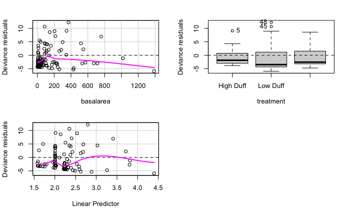

```r
residualPlots(fill1.glm, type="deviance")
```

```r
residuals(fill1.glm, type="deviance")
```

```
          1           2           3           4           5           6           7           8           9          10          11          12          13          14          15          16
 0.20923286  3.52437571 -1.84696896  0.55169766  9.08063242  2.43049570 -1.38139530 -3.85269153 -2.97516095 -2.99178806 -2.98053360 -3.03476511 -3.85618268 -3.03090905  4.05076046 -2.97604160
         17          18          19          20          21          22          23          24          25          26          27          28          29          30          31          32
-2.99110558  4.30805157 -2.36631486 -0.94501752  3.54431734  0.89789475 -2.97441165 -1.85136763 -1.85196037 -0.94785624  0.17193562 -3.01860601  5.48494095  1.16145876 -4.34220066 -5.25716243
         33          34          35          36          37          38          39          40          41          42          43          44          45          46          47          48
-4.32602610 -3.49888536 -3.49517373 -4.29319540 -2.41941660 -3.47184250 -4.38810960 -4.28248340 -4.77859577 -4.28182304  6.97214474 -4.90583052 10.66755976  4.45929577  4.44436791 12.21787559
         49          50          51          52          53          54          55          56          57          58          59          60          61          62          63          64
 8.94763007  4.86958756 -5.92962494 -3.40832404 -1.49205900 -4.36327765 -1.12152934 -3.46773903 -4.46042903  1.56370632 -2.43527977 -4.42660331 -3.87713567 -3.71109682  2.08390937  0.95140425
         65          66          67          68          69          70          71          72          73          74          75          76          77          78          79          80
-1.98548186 -3.51762919  4.11500950 -1.98220634 -4.32655983 -3.71063761 -3.53833655 -5.30155193 -0.63014935 -2.39743624  8.58300081 -3.39841806 -3.78053165 -0.09213929  1.54731185 -3.14245871
         81          82          83          84          85          86          87          88          89          90          91          92          93          94          95          96
 4.99032310 -3.21638933  2.20660594 -1.49845051  7.07694236 -2.71701487 -3.15255411 -4.74932844  2.02824210 -2.47070604 -2.55251080  2.63055203 -3.32358182 -2.13220538 -2.56631805 -3.12496585
         97          98          99
-1.71855808 -3.20060647 -3.50413976
```

```r
influence.measures(fill1.glm)
```

```
Influence measures of
     glm(formula = culm ~ basalarea + treatment + basalarea * treatment,      family = poisson, data = fill) :
```

|  | dfb.1_ | dfb.bslr | dfb.trLD | dfb.tD.P | dfb.b.LD | dfb.bD.P | dffit | cov.r | cook.d | hat | inf |
| --- | --- | --- | --- | --- | --- | --- | --- | --- | --- | --- | --- |
| 1 | 1.220381e-02 | -7.032031e-03 | -1.051450e-02 | -7.989155e-03 | 6.843365e-03 | 5.528192e-03 | 0.01221320 | 1.1266812 | 4.433696e-04 | 0.05312121 |  |
| 2 | 1.264916e-01 | 9.338903e-03 | -1.089820e-01 | -8.280702e-02 | -9.088344e-03 | -7.341727e-03 | 0.16663081 | 1.0542787 | 1.144452e-01 | 0.03584443 |  |
| 3 | -1.066209e-01 | 6.023918e-02 | 9.186195e-02 | 6.979882e-02 | -5.862298e-02 | -4.735670e-02 | -0.10677275 | 1.1105554 | 2.547704e-02 | 0.05210038 |  |
| 4 | 2.590010e-02 | -8.637187e-03 | -2.231488e-02 | -1.695536e-02 | 8.405454e-03 | 6.790076e-03 | 0.02739647 | 1.1096337 | 2.321560e-03 | 0.03954971 |  |
| 5 | 8.433835e-02 | 4.606532e-01 | -7.266383e-02 | -5.521164e-02 | -4.482941e-01 | -3.621400e-01 | 0.64985367 | 0.8162805 | 2.478718e+00 | 0.07237805 | * |
| 6 | 1.152780e-01 | -3.967061e-02 | -9.932067e-02 | -7.546613e-02 | 3.860627e-02 | 3.118683e-02 | 0.12144323 | 1.0859252 | 5.528496e-02 | 0.03986915 |  |
| 7 | -7.364404e-02 | 3.555332e-02 | 6.344988e-02 | 4.821067e-02 | -3.459943e-02 | -2.795004e-02 | -0.07454467 | 1.1101326 | 1.336099e-02 | 0.04602758 |  |
| 8 | -2.280833e-01 | 1.336296e-01 | 1.965109e-01 | 1.493135e-01 | -1.300443e-01 | -1.050521e-01 | -0.22816690 | 1.0632017 | 7.470266e-02 | 0.05404213 |  |
| 9 | -1.601442e-01 | 7.859046e-02 | 1.379763e-01 | 1.048376e-01 | -7.648191e-02 | -6.178346e-02 | -0.16186134 | 1.0806754 | 4.747107e-02 | 0.04652137 |  |
| 10 | -7.779498e-02 | -5.783087e-02 | 6.702622e-02 | 5.092806e-02 | 5.627929e-02 | 4.546342e-02 | -0.15345945 | 1.0750789 | 4.262270e-02 | 0.04176559 |  |

[output cut: 89 more lines]

|  | StudRes | Hat | CookD |
| --- | --- | --- | --- |
| 5 | 9.810900 | 0.07237805 | 2.4787185 |
| 45 | 10.935984 | 0.02327481 | 0.9895175 |
| 48 | 12.545495 | 0.02596443 | 1.3882039 |
| 51 | -9.841300 | 0.69239565 | 33.4253663 |
| 86 | -3.543642 | 0.44774786 | 1.5618564 |

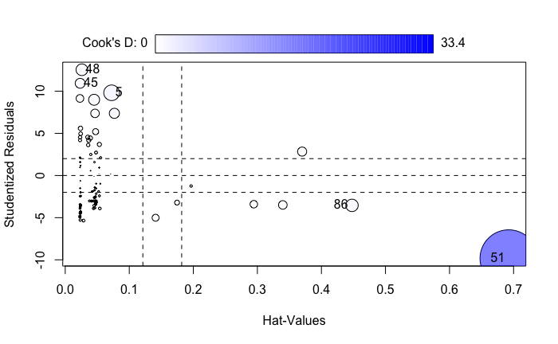

```r
influencePlot(fill1.glm)
```

```r
vif(lm(culm ~ basalarea+treatment+basalarea*treatment, data=fill))
```

```
there are higher-order terms (interactions) in this model
consider setting type = 'predictor'; see ?vif
```

```
                        GVIF Df GVIF^(1/(2*Df))
basalarea           4.832804  1        2.198364
treatment           2.439885  2        1.249805
basalarea:treatment 8.588810  2        1.711919
```

Check collinearity - OK

### Test interaction

```r
fill2.glm <- glm(culm~basalarea+treatment, family=poisson, data=fill)
lrtest(fill1.glm, fill2.glm)
```

```
Likelihood ratio test

Model 1: culm ~ basalarea + treatment + basalarea * treatment
Model 2: culm ~ basalarea + treatment
  #Df  LogLik Df  Chisq Pr(>Chisq)
1   6 -939.64
2   4 -984.50 -2 89.733  < 2.2e-16 ***
---
Signif. codes:  0 ‘***’ 0.001 ‘**’ 0.01 ‘*’ 0.05 ‘.’ 0.1 ‘ ’ 1
```

Get analysis of deviance table

```r
anova(fill1.glm, test="LRT")
```

```
Analysis of Deviance Table

Model: poisson, link: log

Response: culm

Terms added sequentially (first to last)

                    Df Deviance Resid. Df Resid. Dev  Pr(>Chi)
NULL                                   98     2101.6
basalarea            1   372.99        97     1728.6 < 2.2e-16 ***
treatment            2    39.02        95     1689.6 3.371e-09 ***
basalarea:treatment  2    89.73        93     1599.8 < 2.2e-16 ***
---
Signif. codes:  0 ‘***’ 0.001 ‘**’ 0.01 ‘*’ 0.05 ‘.’ 0.1 ‘ ’ 1
```

### Check overdispersion by calculating dispersion statistic

```r
presid1 <- resid(fill1.glm, type="pearson")
ssize1 <- nrow(fill)
params1 <- length(coef(fill1.glm))
disp1 <- sum(presid1^2)/(ssize1-params1)
disp1
```

[output not shown]

**Note** residual deviance >> residual df and dispersion stat >> 1 so overdispersed. Might be better with negative binomial rather than poisson.

## Fit neg binomial

```r
fill1.nb <- glm.nb(culm~basalarea+treatment+basalarea*treatment, data=fill)
summary(fill1.nb)
```

```
Call:
glm.nb(formula = culm ~ basalarea + treatment + basalarea * treatment,
    data = fill, init.theta = 0.4727266654, link = log)

Deviance Residuals:
    Min       1Q   Median       3Q      Max
-1.8019  -1.1184  -0.7019   0.1692   2.0097

Coefficients:
                                          Estimate Std. Error z value Pr(>|z|)
(Intercept)                              1.999e+00  3.564e-01   5.609 2.04e-08 ***
basalarea                                7.592e-05  1.455e-03   0.052   0.9584
treatmentLow Duff                       -1.606e-01  4.408e-01  -0.364   0.7155
treatmentLow Duff + Pinecones           -7.506e-01  5.325e-01  -1.410   0.1587
basalarea:treatmentLow Duff              3.038e-03  1.658e-03   1.833   0.0668 .
basalarea:treatmentLow Duff + Pinecones  5.557e-03  2.347e-03   2.368   0.0179 *
---
Signif. codes:  0 ‘***’ 0.001 ‘**’ 0.01 ‘*’ 0.05 ‘.’ 0.1 ‘ ’ 1

(Dispersion parameter for Negative Binomial(0.4727) family taken to be 1)

    Null deviance: 132.36  on 98  degrees of freedom
Residual deviance: 110.35  on 93  degrees of freedom
AIC: 627.85

Number of Fisher Scoring iterations: 1

              Theta:  0.4727
          Std. Err.:  0.0722

 2 x log-likelihood:  -613.8500
```

```r
AICc(fill1.nb)
```

```
[1] 629.0806
```

```r
fill2.nb <- glm.nb(culm~basalarea+treatment, data=fill)
lrtest(fill1.nb, fill2.nb)
```

```
Likelihood ratio test

Model 1: culm ~ basalarea + treatment + basalarea * treatment
Model 2: culm ~ basalarea + treatment
  #Df  LogLik Df  Chisq Pr(>Chisq)
1   7 -306.93
2   5 -308.54 -2 3.2376     0.1981
```

```r
summary(fill2.nb)
```

```
Call:
glm.nb(formula = culm ~ basalarea + treatment, data = fill, init.theta = 0.456240813,
    link = log)

Deviance Residuals:
    Min       1Q   Median       3Q      Max
-1.7782  -1.3744  -0.6591   0.2705   1.9715

Coefficients:
                               Estimate Std. Error z value Pr(>|z|)
(Intercept)                   1.6237482  0.3057921   5.310 1.10e-07 ***
basalarea                     0.0030786  0.0006616   4.653 3.26e-06 ***
treatmentLow Duff             0.2203827  0.3654880   0.603    0.547
treatmentLow Duff + Pinecones 0.0282148  0.4203121   0.067    0.946
---
Signif. codes:  0 ‘***’ 0.001 ‘**’ 0.01 ‘*’ 0.05 ‘.’ 0.1 ‘ ’ 1

(Dispersion parameter for Negative Binomial(0.4562) family taken to be 1)

    Null deviance: 128.58  on 98  degrees of freedom
Residual deviance: 110.49  on 95  degrees of freedom
AIC: 627.09

Number of Fisher Scoring iterations: 1

              Theta:  0.4562
          Std. Err.:  0.0691

 2 x log-likelihood:  -617.0870
```

```r
AICc(fill2.nb)
```

```
[1] 627.7326
```

```r
fill3.nb <- glm.nb(culm~basalarea, data=fill)
summary(fill3.nb)
```

```
Call:
glm.nb(formula = culm ~ basalarea, data = fill, init.theta = 0.4538768096,
    link = log)

Deviance Residuals:
    Min       1Q   Median       3Q      Max
-1.7504  -1.3788  -0.7063   0.2963   2.1243

Coefficients:
             Estimate Std. Error z value Pr(>|z|)
(Intercept) 1.7282676  0.1855371   9.315   <2e-16 ***
basalarea   0.0031460  0.0006618   4.754    2e-06 ***
---
Signif. codes:  0 ‘***’ 0.001 ‘**’ 0.01 ‘*’ 0.05 ‘.’ 0.1 ‘ ’ 1

(Dispersion parameter for Negative Binomial(0.4539) family taken to be 1)

    Null deviance: 128.03  on 98  degrees of freedom
Residual deviance: 110.49  on 97  degrees of freedom
AIC: 623.54

Number of Fisher Scoring iterations: 1

              Theta:  0.4539
          Std. Err.:  0.0686

 2 x log-likelihood:  -617.5430
```

```r
AICc(fill3.nb)
```

```
[1] 623.7958
```

```r
lrtest(fill2.nb, fill3.nb)
```

```
Likelihood ratio test

Model 1: culm ~ basalarea + treatment
Model 2: culm ~ basalarea
  #Df  LogLik Df  Chisq Pr(>Chisq)
1   5 -308.54
2   3 -308.77 -2 0.4557     0.7962
```

```r
fill4.nb <- glm.nb(culm~treatment, data=fill)
lrtest(fill2.nb, fill4.nb)
```

```
Likelihood ratio test

Model 1: culm ~ basalarea + treatment
Model 2: culm ~ treatment
  #Df  LogLik Df  Chisq Pr(>Chisq)
1   5 -308.54
2   4 -315.69 -1 14.296  0.0001562 ***
---
Signif. codes:  0 ‘***’ 0.001 ‘**’ 0.01 ‘*’ 0.05 ‘.’ 0.1 ‘ ’ 1
```

```r
anova(fill1.nb, test="LRT")
```

```
Analysis of Deviance Table

Model: Negative Binomial(0.4727), link: log

Response: culm

Terms added sequentially (first to last)

                    Df Deviance Resid. Df Resid. Dev Pr(>Chi)
NULL                                   98     132.36
basalarea            1  18.2374        97     114.12 1.95e-05 ***
treatment            2   0.4734        95     113.64   0.7892
basalarea:treatment  2   3.2929        93     110.35   0.1927
---
Signif. codes:  0 ‘***’ 0.001 ‘**’ 0.01 ‘*’ 0.05 ‘.’ 0.1 ‘ ’ 1
```

Check diagnostics

```
          Test stat Pr(>|Test stat|)
basalarea    8.8463         0.002937 **
treatment
---
Signif. codes:  0 ‘***’ 0.001 ‘**’ 0.01 ‘*’ 0.05 ‘.’ 0.1 ‘ ’ 1
```

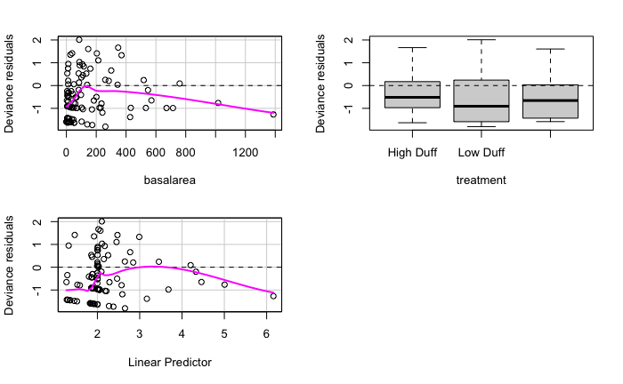

```r
residualPlots(fill1.nb, type="deviance")
```

```r
influence.measures(fill1.nb)
```

```
Influence measures of
     glm.nb(formula = culm ~ basalarea + treatment + basalarea * treatment,      data = fill, init.theta = 0.4727266654, link = log) :
```

|  | dfb.1_ | dfb.bslr | dfb.trLD | dfb.tD.P | dfb.b.LD | dfb.bD.P | dffit | cov.r | cook.d | hat | inf |
| --- | --- | --- | --- | --- | --- | --- | --- | --- | --- | --- | --- |
| 1 | 1.198797e-02 | -6.889872e-03 | -9.693108e-03 | -8.022972e-03 | 6.046704e-03 | 4.271291e-03 | 0.011997365 | 1.1268492 | 3.030832e-05 | 0.05325625 |  |
| 2 | 1.006753e-01 | 8.487067e-03 | -8.140299e-02 | -6.737714e-02 | -7.448437e-03 | -5.261452e-03 | 0.133328118 | 1.0728284 | 6.807622e-03 | 0.03586184 |  |
| 3 | -1.136559e-01 | 6.403202e-02 | 9.189871e-02 | 7.606444e-02 | -5.619592e-02 | -3.969586e-02 | -0.113820678 | 1.1086941 | 1.518876e-03 | 0.05221973 |  |
| 4 | 2.364160e-02 | -7.782550e-03 | -1.911587e-02 | -1.582218e-02 | 6.830138e-03 | 4.824696e-03 | 0.025034869 | 1.1098205 | 1.421549e-04 | 0.03952375 |  |
| 5 | 5.582012e-02 | 3.200260e-01 | -4.513444e-02 | -3.735772e-02 | -2.808619e-01 | -1.983962e-01 | 0.448435310 | 0.9761536 | 1.452134e-01 | 0.07284721 |  |
| 6 | 9.619334e-02 | -3.270331e-02 | -7.777899e-02 | -6.437756e-02 | 2.870114e-02 | 2.027401e-02 | 0.101440630 | 1.0934920 | 3.329576e-03 | 0.03984505 |  |
| 7 | -7.503652e-02 | 3.603887e-02 | 6.067223e-02 | 5.021833e-02 | -3.162851e-02 | -2.234186e-02 | -0.075971469 | 1.1098591 | 7.925694e-04 | 0.04606311 |  |
| 8 | -3.709661e-01 | 2.168277e-01 | 2.999518e-01 | 2.482697e-01 | -1.902928e-01 | -1.344197e-01 | -0.371104505 | 0.9664137 | 4.485783e-03 | 0.05419167 |  |
| 9 | -1.985245e-01 | 9.694930e-02 | 1.605208e-01 | 1.328628e-01 | -8.508485e-02 | -6.010252e-02 | -0.200693035 | 1.0607751 | 2.837857e-03 | 0.04656299 |  |
| 10 | -9.549601e-02 | -7.334373e-02 | 7.721515e-02 | 6.391088e-02 | 6.436808e-02 | 4.546854e-02 | -0.190654724 | 1.0552569 | 2.544479e-03 | 0.04193328 |  |

[output cut: 89 more lines]

|  | StudRes | Hat | CookD |
| --- | --- | --- | --- |
| 5 | 1.7507591 | 0.07284721 | 0.14521340 |
| 45 | 1.9719789 | 0.02378786 | 0.07692456 |
| 51 | -1.2954878 | 0.46334733 | 0.10910362 |
| 86 | -0.6688643 | 0.33998104 | 0.02794775 |

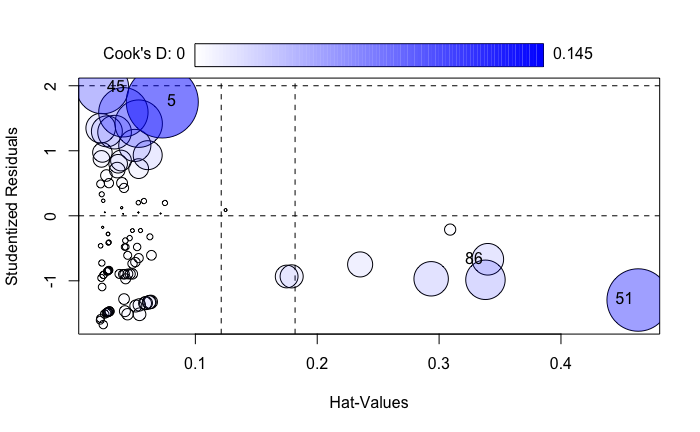

```r
influencePlot(fill1.nb)
```

Dispersion statistic (note add 1 to parameters because of estimating k)

```r
nbresid <- resid(fill1.nb, type="pearson")
nbssize <- nrow(fill)
nbparams <- length(coef(fill1.nb))+1
nbdisp <- sum(nbresid^2)/(nbssize-nbparams)
nbdisp
```

```
[1] 1.0892
```

Dispersion statistic just over 1 so much better.

## Compare to quasi-Poisson as an alternative

```r
fill.qp <- glm(culm~basalarea+treatment+basalarea*treatment, family=quasipoisson, data=fill)
fill.qp$theta
```

```r
summary(fill.qp)
```

```
Call:
glm(formula = culm ~ basalarea + treatment + basalarea * treatment,
    family = quasipoisson, data = fill)

Deviance Residuals:
   Min      1Q  Median      3Q     Max
-5.930  -3.502  -2.471   1.056  12.218

Coefficients:
                                          Estimate Std. Error t value Pr(>|t|)
(Intercept)                              2.0040614  0.4001547   5.008  2.6e-06 ***
basalarea                                0.0000407  0.0016212   0.025   0.9800
treatmentLow Duff                        0.2112408  0.4644455   0.455   0.6503
treatmentLow Duff + Pinecones           -0.4384083  0.6112549  -0.717   0.4750
basalarea:treatmentLow Duff              0.0015309  0.0016659   0.919   0.3605
basalarea:treatmentLow Duff + Pinecones  0.0038881  0.0020622   1.885   0.0625 .
---
Signif. codes:  0 ‘***’ 0.001 ‘**’ 0.01 ‘*’ 0.05 ‘.’ 0.1 ‘ ’ 1

(Dispersion parameter for quasipoisson family taken to be 21.12124)

    Null deviance: 2101.6  on 98  degrees of freedom
Residual deviance: 1599.9  on 93  degrees of freedom
AIC: NA

Number of Fisher Scoring iterations: 6
```

```r
anova(fill.qp, test="LRT")
```

```
Analysis of Deviance Table

Model: quasipoisson, link: log

Response: culm

Terms added sequentially (first to last)

                    Df Deviance Resid. Df Resid. Dev  Pr(>Chi)
NULL                                   98     2101.6
basalarea            1   372.99        97     1728.6 2.642e-05 ***
treatment            2    39.02        95     1689.6    0.3971
basalarea:treatment  2    89.73        93     1599.8    0.1195
---
Signif. codes:  0 ‘***’ 0.001 ‘**’ 0.01 ‘*’ 0.05 ‘.’ 0.1 ‘ ’ 1
```

```
          Test stat Pr(>|Test stat|)
basalarea    247.27        < 2.2e-16 ***
treatment
---
Signif. codes:  0 ‘***’ 0.001 ‘**’ 0.01 ‘*’ 0.05 ‘.’ 0.1 ‘ ’ 1
```

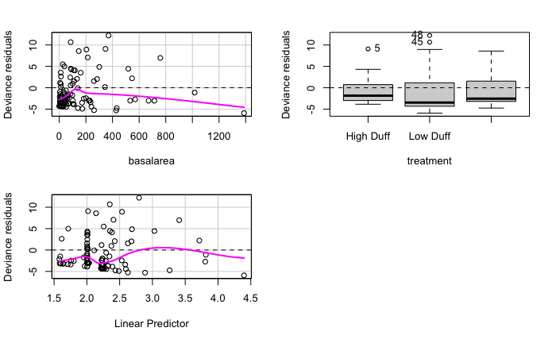

```r
residualPlots(fill.qp, type="deviance")
```

```r
influence.measures(fill.qp)
```

```
Influence measures of
     glm(formula = culm ~ basalarea + treatment + basalarea * treatment,      family = quasipoisson, data = fill) :
```

|  | dfb.1_ | dfb.bslr | dfb.trLD | dfb.tD.P | dfb.b.LD | dfb.bD.P | dffit | cov.r | cook.d | hat | inf |
| --- | --- | --- | --- | --- | --- | --- | --- | --- | --- | --- | --- |
| 1 | 1.220381e-02 | -7.032031e-03 | -1.051450e-02 | -7.989155e-03 | 6.843365e-03 | 5.528192e-03 | 0.01221320 | 1.1266812 | 2.099164e-05 | 0.05312121 |  |
| 2 | 1.264916e-01 | 9.338903e-03 | -1.089820e-01 | -8.280702e-02 | -9.088344e-03 | -7.341727e-03 | 0.16663081 | 1.0542787 | 5.418487e-03 | 0.03584443 |  |
| 3 | -1.066209e-01 | 6.023918e-02 | 9.186195e-02 | 6.979882e-02 | -5.862298e-02 | -4.735670e-02 | -0.10677275 | 1.1105554 | 1.206228e-03 | 0.05210038 |  |
| 4 | 2.590010e-02 | -8.637187e-03 | -2.231488e-02 | -1.695536e-02 | 8.405454e-03 | 6.790076e-03 | 0.02739647 | 1.1096337 | 1.099159e-04 | 0.03954971 |  |
| 5 | 8.433835e-02 | 4.606532e-01 | -7.266383e-02 | -5.521164e-02 | -4.482941e-01 | -3.621400e-01 | 0.64985367 | 0.8162805 | 1.173567e-01 | 0.07237805 |  |
| 6 | 1.152780e-01 | -3.967061e-02 | -9.932067e-02 | -7.546613e-02 | 3.860627e-02 | 3.118683e-02 | 0.12144323 | 1.0859252 | 2.617505e-03 | 0.03986915 |  |
| 7 | -7.364404e-02 | 3.555332e-02 | 6.344988e-02 | 4.821067e-02 | -3.459943e-02 | -2.795004e-02 | -0.07454467 | 1.1101326 | 6.325852e-04 | 0.04602758 |  |
| 8 | -2.280833e-01 | 1.336296e-01 | 1.965109e-01 | 1.493135e-01 | -1.300443e-01 | -1.050521e-01 | -0.22816690 | 1.0632017 | 3.536850e-03 | 0.05404213 |  |
| 9 | -1.601442e-01 | 7.859046e-02 | 1.379763e-01 | 1.048376e-01 | -7.648191e-02 | -6.178346e-02 | -0.16186134 | 1.0806754 | 2.247551e-03 | 0.04652137 |  |
| 10 | -7.779498e-02 | -5.783087e-02 | 6.702622e-02 | 5.092806e-02 | 5.627929e-02 | 4.546342e-02 | -0.15345945 | 1.0750789 | 2.018002e-03 | 0.04176559 |  |

[output cut: 89 more lines]

|  | StudRes | Hat | CookD |
| --- | --- | --- | --- |
| 5 | 2.4208948 | 0.07237805 | 0.11735666 |
| 45 | 2.7235202 | 0.02327481 | 0.04684940 |
| 48 | 3.1637903 | 0.02596443 | 0.06572549 |
| 51 | -2.4490785 | 0.69239565 | 1.58254735 |
| 86 | -0.8533468 | 0.44774786 | 0.07394718 |

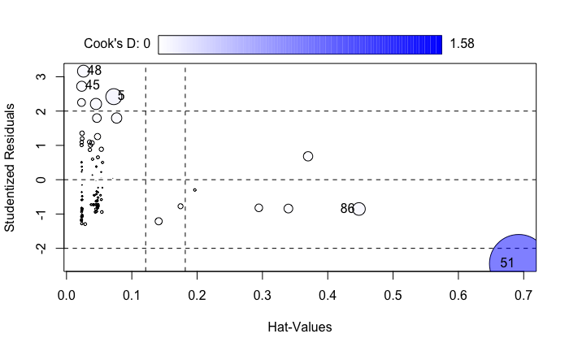

```r
influencePlot(fill.qp)
```

## Compare with two additive zinb models

Check predicted number of zeros from -ve binomial first observed number (ignoring treatments)

```r
zerobs <- fill$culm == 0
propzerobs <- sum(zerobs)/nrow(fill)
propzerobs
```

```
[1] 0.2222222
```

Second, predicted number from -ve binomial

```r
munb <- exp(predict(fill2.nb))
theta <- fill2.nb$theta
znb <- dnbinom(0, mu=munb, size=theta)
mean(znb)
```

```
[1] 0.2588404
```

### ZIP1

```r
fill1.zip <- zeroinfl(culm~basalarea+treatment|1, data=fill, dist="negbin")
summary(fill1.zip)
```

```
Call:
zeroinfl(formula = culm ~ basalarea + treatment | 1, data = fill, dist = "negbin")

Pearson residuals:
    Min      1Q  Median      3Q     Max
-0.6648 -0.6423 -0.4645  0.3081  4.2149

Count model coefficients (negbin with log link):
                                Estimate Std. Error z value Pr(>|z|)
(Intercept)                    1.6237408  0.3050987   5.322 1.03e-07 ***
basalarea                      0.0030787  0.0009237   3.333 0.000859 ***
treatmentLow Duff              0.2203466  0.3709882   0.594 0.552549
treatmentLow Duff + Pinecones  0.0282734  0.4263062   0.066 0.947122
Log(theta)                    -0.7847333  0.1513783  -5.184 2.17e-07 ***

Zero-inflation model coefficients (binomial with logit link):
            Estimate Std. Error z value Pr(>|z|)
(Intercept)   -10.33      37.93  -0.272    0.785
---
Signif. codes:  0 '***' 0.001 '**' 0.01 '*' 0.05 '.' 0.1 ' ' 1

Theta = 0.4562
Number of iterations in BFGS optimization: 27
Log-likelihood: -308.5 on 6 Df
```

```r
AIC(fill1.zip)
```

```
[1] 629.0888
```

### ZIP2

```r
fill2.zip <- zeroinfl(culm~basalarea+treatment|basalarea+treatment, data=fill, dist="negbin")
summary(fill2.zip)
```

```
Call:
zeroinfl(formula = culm ~ basalarea + treatment | basalarea + treatment, data = fill, dist = "negbin")

Pearson residuals:
    Min      1Q  Median      3Q     Max
-0.7413 -0.6068 -0.4402  0.2948  3.8557

Count model coefficients (negbin with log link):
                                Estimate Std. Error z value Pr(>|z|)
(Intercept)                    1.6988429  0.2759555   6.156 7.45e-10 ***
basalarea                      0.0023910  0.0008009   2.985  0.00283 **
treatmentLow Duff              0.3839040  0.3505127   1.095  0.27340
treatmentLow Duff + Pinecones  0.3399303  0.4220126   0.805  0.42053
Log(theta)                    -0.5612528  0.1732613  -3.239  0.00120 **

Zero-inflation model coefficients (binomial with logit link):
                               Estimate Std. Error z value Pr(>|z|)
(Intercept)                   -10.41990  100.79578  -0.103    0.918
basalarea                      -0.03281    0.02478  -1.325    0.185
treatmentLow Duff               9.61626  100.79708   0.095    0.924
treatmentLow Duff + Pinecones  10.86463  100.79652   0.108    0.914
---
Signif. codes:  0 '***' 0.001 '**' 0.01 '*' 0.05 '.' 0.1 ' ' 1

Theta = 0.5705
Number of iterations in BFGS optimization: 39
Log-likelihood: -305.1 on 9 Df
```

```r
AIC(fill2.zip)
```

```
[1] 628.2313
```

```r
lrtest(fill1.zip, fill2.zip)
```

```
Likelihood ratio test

Model 1: culm ~ basalarea + treatment | 1
Model 2: culm ~ basalarea + treatment | basalarea + treatment
  #Df  LogLik Df  Chisq Pr(>Chisq)
1   6 -308.54
2   9 -305.12  3 6.8576    0.07658 .
---
Signif. codes:  0 ‘***’ 0.001 ‘**’ 0.01 ‘*’ 0.05 ‘.’ 0.1 ‘ ’ 1
```

## Compare with linear model

```r
fill.lm <- lm(culm~basalarea+treatment+basalarea*treatment, data=fill)
summary(fill.lm)
```

```
Call:
lm(formula = culm ~ basalarea + treatment + basalarea * treatment,
    data = fill)

Residuals:
    Min      1Q  Median      3Q     Max
-29.845  -7.205  -4.438   2.682  64.961

Coefficients:
                                          Estimate Std. Error t value Pr(>|t|)
(Intercept)                              7.4189045  3.6380246   2.039   0.0443 *
basalarea                                0.0003059  0.0148651   0.021   0.9836
treatmentLow Duff                       -0.5594368  4.5020291  -0.124   0.9014
treatmentLow Duff + Pinecones           -5.2046325  5.3840301  -0.967   0.3362
basalarea:treatmentLow Duff              0.0407534  0.0170275   2.393   0.0187 *
basalarea:treatmentLow Duff + Pinecones  0.0626570  0.0241614   2.593   0.0110 *
---
Signif. codes:  0 ‘***’ 0.001 ‘**’ 0.01 ‘*’ 0.05 ‘.’ 0.1 ‘ ’ 1

Residual standard error: 15.31 on 93 degrees of freedom
Multiple R-squared:  0.292, Adjusted R-squared:  0.2539
F-statistic: 7.669 on 5 and 93 DF,  p-value: 4.502e-06
```

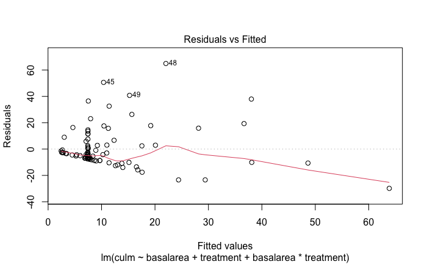

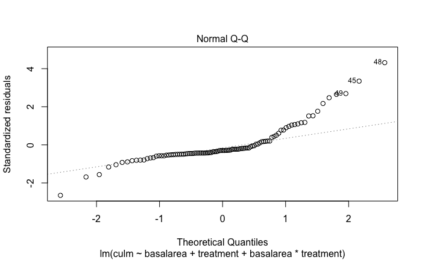

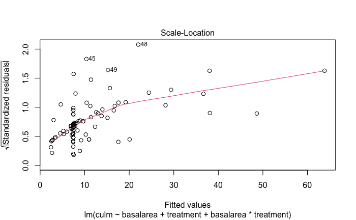

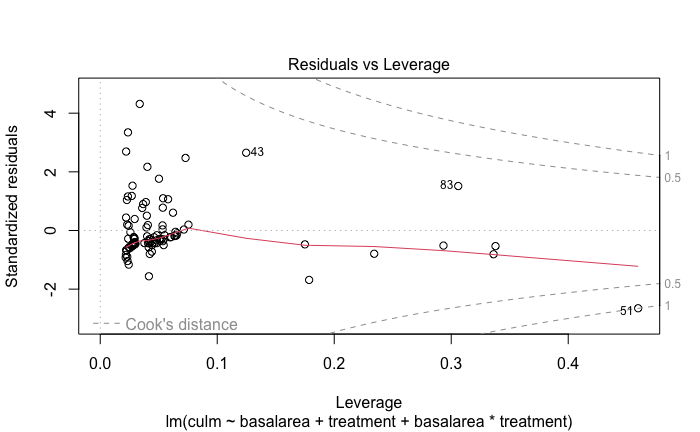

```r
plot(fill.lm)
```

```r
AIC(fill.lm)
```

```
[1] 829.0305
```

### Try linear with sqrt transform

```r
fill.lm <- lm(sqrt(culm)~basalarea+treatment+basalarea*treatment, data=fill)
summary(fill.lm)
```

```
Call:
lm(formula = sqrt(culm) ~ basalarea + treatment + basalarea *
    treatment, data = fill)

Residuals:
    Min      1Q  Median      3Q     Max
-3.0962 -1.2761 -0.7173  1.1725  5.7084

Coefficients:
                                          Estimate Std. Error t value Pr(>|t|)
(Intercept)                              2.3126014  0.4828446   4.790  6.3e-06 ***
basalarea                               -0.0005668  0.0019729  -0.287  0.77452
treatmentLow Duff                       -0.6210459  0.5975168  -1.039  0.30132
treatmentLow Duff + Pinecones           -1.3296171  0.7145774  -1.861  0.06595 .
basalarea:treatmentLow Duff              0.0057803  0.0022599   2.558  0.01215 *
basalarea:treatmentLow Duff + Pinecones  0.0101563  0.0032067   3.167  0.00208 **
---
Signif. codes:  0 ‘***’ 0.001 ‘**’ 0.01 ‘*’ 0.05 ‘.’ 0.1 ‘ ’ 1

Residual standard error: 2.032 on 93 degrees of freedom
Multiple R-squared:  0.2872,    Adjusted R-squared:  0.2489
F-statistic: 7.495 on 5 and 93 DF,  p-value: 5.999e-06
```

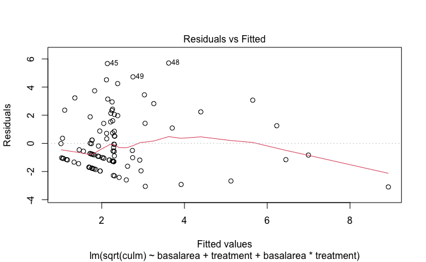

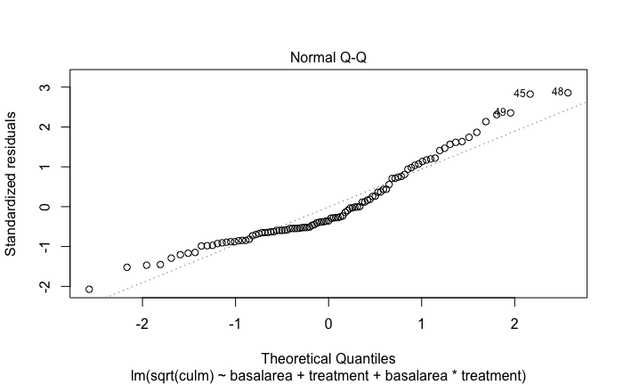

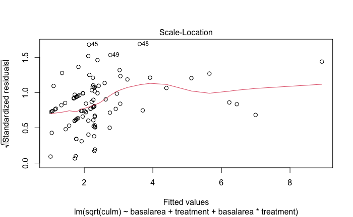

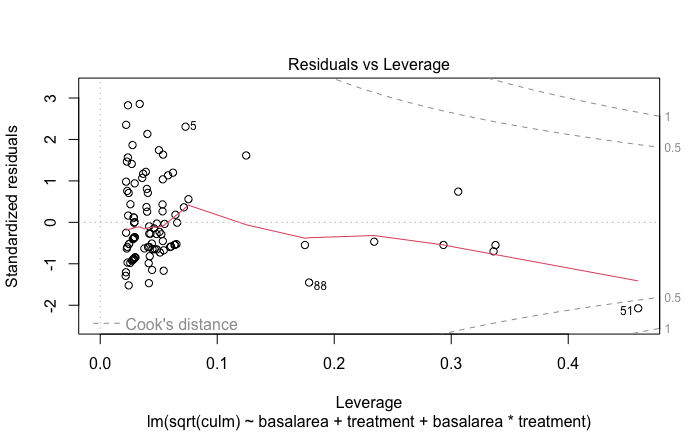

```r
plot(fill.lm)
```

```r
AIC(fill.lm)
```

```
[1] 429.1693
```